# PS11

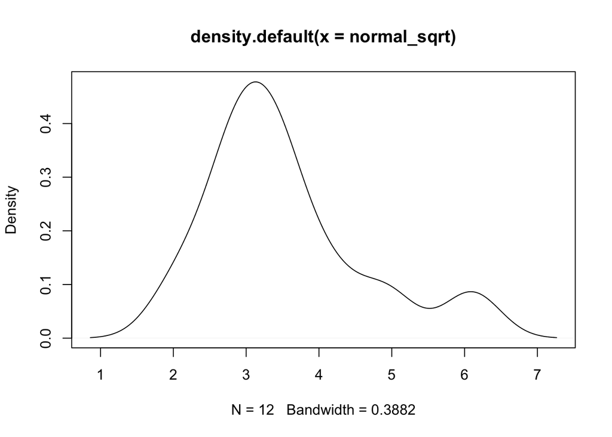

```r
plot(density(normal_sqrt))
```

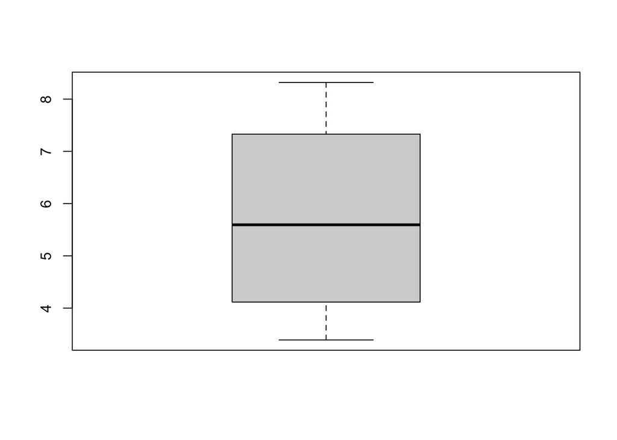

```r
# diabetic sample sqrt
boxplot(diabetic_sqrt)
```

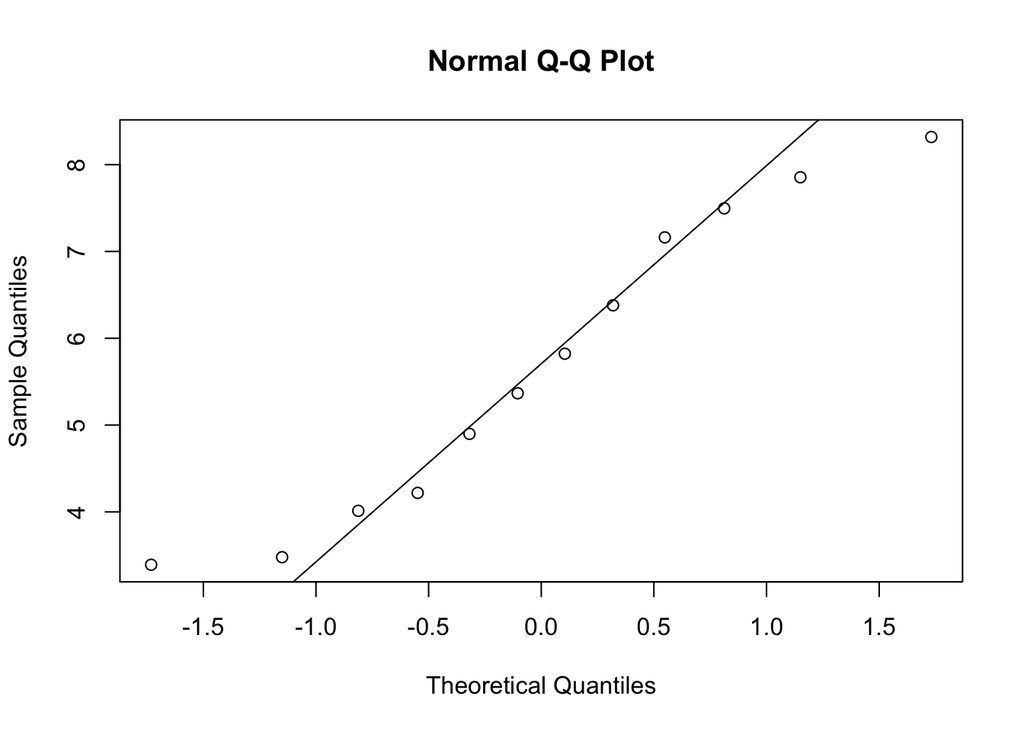

```r
qqnorm(diabetic_sqrt)
qqline(diabetic_sqrt)
```

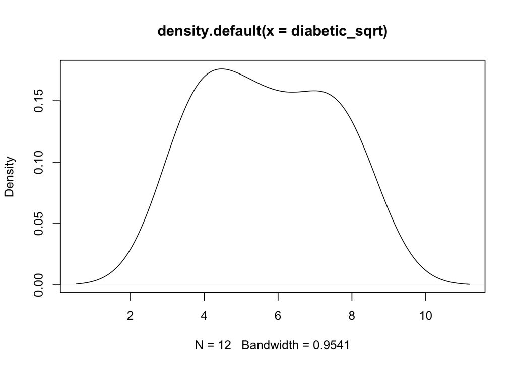

```r
plot(density(diabetic_sqrt))
```

```r
# The plots that compare the quantiles of the square root transformed samples display some curvature, particularly in the diabetic sample. This suggests that the transformed measurements might still have some departure from normality.
```

# c)

```r
n = length(normal_log)
mu1 = mean(normal_log)
mu2 = mean(diabetic_log)
std1 = sd(normal_log)
std2 = sd(diabetic_log)
v1 = std1^2
v2 = std1^2
se = sqrt((v1 / n) + (v2/n))
df = (v1+v2)^2/(v1^2/(n-1)+v2^2/(n-1))
t = (mu1 - mu2) / sqrt(v1/n + v2/n)
t
```

```
## [1] -3.939633
```

```r
p = 2*pt(t,df)
p
```

```
## [1] 0.0006986983
```

# d)

```r
# Calculate the observed difference in means

#library(infer)
#dataframe = data.frame(group = c(rep("Normal", 12), rep("Diabetic", 12)), values = log(c(diabetic, normal)))
#null_dist = dataframe %>%
#  specify(values ~ group) %>%
#  hypothesize(null = "independence") %>%
#  generate(reps = 1000, type = "permute") %>%
#  calculate(stat = "diff in means", order = c("diabetic", "normal"))
#d_hat = data.patients %>%
#  specify(patients ~ group) %>%
#  calculate(stat = "diff in means", order = c("diabetic", "normal"))
#d_hat


# The resulting p-value is approximately 0, which is less than the commonly used
# threshold for statistical significance of 0.05.
# Therefore, we can conclude that the evidence strongly supports the researchers' claim.
```

[output not shown]

[output not shown]

## Q3

```r
# Referred - S520_040423_notes_2-sample_problems.pdf
# Referred - S520_040623_2-sample_examples_updated.R
```

Utilize the bechdel dataset from the fivethirtyeight package. Assume that the dataset represents the entire population and collect a sample of 60 movies that passed the Bechdel test and another sample of 72 movies that failed the Bechdel test. Prior to obtaining the samples, set the seed to 100. The objective is to determine whether movies that fail the Bechdel test are more profitable, where profit is defined as domgross - budget. 1. Retrieve the R code to obtain the necessary data. 2. Determine whether this is a one-sample or two-sample test, identify the parameter(s) of interest, and state the hypotheses. 3. Perform the test, calculate the test statistic, p-value, and draw a conclusion using the theory-based method. 4. Repeat step 3 using the simulation-based approach. 5. Use the theory-based method to obtain a 97% confidence interval for the average difference in profit (pass - fail). 6. Repeat step 5 using the simulation-based approach. Here is some code to get you started

```r
library(fivethirtyeight)
library(tidyverse)
library(infer)

#View(bechdel)

set.seed(100)

# 1)
# A sample of 60 movies that passed the Bechdel test

df_pass <- bechdel |>
  na.omit() |>
  filter(binary == "PASS") |>
  slice_sample(n = 60) |>
  mutate(profit = domgross - budget)

# sample of 72 movies that failed the Bechdel test

df_fail <- bechdel |>
  na.omit() |>
  filter(binary == "FAIL") |>
  slice_sample(n = 72)|>
  mutate(profit = domgross - budget)

df_final <- rbind(df_pass, df_fail)
```

2. In this study, the unit of analysis is a movie. The researcher samples movies from two distinct populations: one population consists of movies that have passed the Bechdel test, while the other population consists of movies that have failed the Bechdel test. Since the researcher is comparing two populations, this is a two-sample problem. The variable of interest is whether or not a movie passed the Bechdel test, which serves as a binary measurement for each movie. To clarify, let X_i represent the ith movie that passed the Bechdel test, while Y_j represents the jth movie that failed the Bechdel test. The parameter of interest is the difference between the means of the two populations, denoted by delta = mu_1 - mu_2. The null hypothesis for this study is that there is no difference between the means of the two populations. More specifically, the null hypothesis can be expressed as H_0: delta = 0, while the alternative hypothesis is H_1: delta != 0.
3. Theory Approach-

```r
# X_i = mu_1 for i = 1,...,60
# Y_j = mu_2 for j = 1,...,72

t_test <- df_final |>
  t_test(formula = profit ~ binary, order = c("PASS", "FAIL"))

test_statistic <- t_test$statistic
test_statistic
```

```
##        t
## 1.553952
```

```r
p_value <- t_test$p_value
p_value
```

```
## [1] 0.1226952
```

```r
# Based on the obtained p-value of 0.122 at a significance level of 0.05, we cannot reject the null hypothesis. Hence, there is insufficient evidence to support the claim that the average profit of movies that do not pass the Bechdel test is higher than the average profit of movies that pass the Bechdel test. movies that pass the Bechdel test.
```

4. Simulation approach

```r
d_hat <- df_final |>
  specify(profit ~ binary) |>
  calculate(stat = "diff in means", order = c("PASS", "FAIL"))

d_hat
```

```
## Response: profit (numeric)
## Explanatory: binary (factor)
## # A tibble: 1 × 1
##        stat
##       <dbl>
## 1 13044949.
```

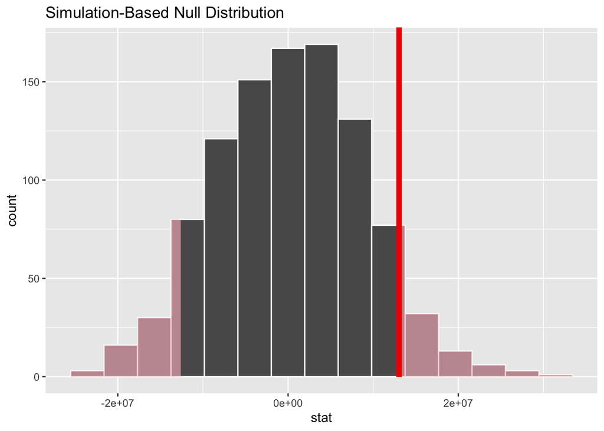

```r
null_dist <- df_final |>
  specify(profit ~ binary) |>
  hypothesize(null = "independence") |>
  generate(reps = 1000, type = "permute") |>
  calculate(stat = "diff in means", order = c("PASS", "FAIL"))

visualize(null_dist) +
  shade_p_value(obs_stat = d_hat, direction = "two-sided")
```

```r
null_dist |>
  get_p_value(obs_stat = d_hat, direction = "two-sided")
```

```
## # A tibble: 1 × 1
##   p_value
##     <dbl>
## 1    0.13
```

```r
# 5) Theory based CI = 97%
x_bar =  mean(df_pass$profit)
y_bar = mean(df_fail$profit)
s_1 = sd(df_pass$profit)
s_2 = sd(df_fail$profit)
n_1 = length(df_pass$profit)
n_2 = length(df_fail$profit)
se = sqrt(s_1^2/n_1 + s_2^2/n_2)
se
```

```
## [1] 8394691
```

```r
t_stat = (x_bar - y_bar - 0)/se
t_stat
```

```
## [1] 1.553952
```

```r
nu.hat = (s_1^2/n_1+s_2^2/n_2)^2/((s_1^2/n_1)^2/(n_1-1) + (s_2^2/n_2)^2/(n_2-1))
nu.hat
```

```
## [1] 126.4454
```

```r
alpha = 1- 0.97
q = qnorm(1-alpha/2)

c(nu.hat-q*se, nu.hat+q*se)
```

```
## [1] -18217112  18217365
```

```r
# 6) Simulation based CI = 97%

library(infer)

null_sim <-  df_final |>
  specify(profit ~ binary) |>
  #hypothesize(null = "point", mu = ) |>
  generate(reps = 1000, type = "bootstrap") |>
  calculate(stat = "diff in means", order = c("PASS", "FAIL"))
percentile_ci <- get_ci(null_sim, level = 0.97)
percentile_ci
```

```
## # A tibble: 1 × 2
##    lower_ci  upper_ci
##       <dbl>     <dbl>
## 1 -4506540. 30857010.
```